# A Statistical and Visual Analysis of Municipally-Maintained Trees in the City of Burlington, VT

Isabelle Franke, Caroline Green, Will Guisbond

4/15/2022

# 1 Introduction

# 2 Visualization & Analysis

## 2.1 Data Cleaning

```r
# read in csv file
trees <- read.csv("./Burlington_Trees.csv")
library("magrittr")

# separate Geo.Point column to latitude and longitude
# and convert to numeric variables
trees <- trees %>%
         separate(Geo.Point, c("lat", "long"), ",") %>%
         mutate(lat = as.numeric(lat),
                long = as.numeric(long))

# separate species column into genus, species
trees <- trees %>%
         separate(species, c("genus", "species"), ",")
# remove the "spp" included as a place holder for genus
trees$genus <- gsub(" spp", "", trees$genus)

# correct the misspelling of mapl to maple
trees$genus <- gsub("mapl", "maple", trees$genus, fixed = TRUE)
trees$genus <- gsub("maplee", "maple", trees$genus)

# convert zeros in numeric columns to NA so they will not be included in graphs
# in this case, zero values are due to lack of information, not lack of value,
# so all were converted to NA values to be filtered out later
# repeat for blank values
trees[trees == 0] <- NA
trees[trees == ""] <- NA

# convert dates to better format
trees <- trees %>%
  mutate(modified = as.yearmon(modified, "%m/%Y"))

# cleaned data frame
head(trees)
```

|  | lat | long | zone_id | site_id | modified | park | landuse | site_typ | genus | species | diameter | height | spread | trunks | conditn | appraise | planted |
| --- | --- | --- | --- | --- | --- | --- | --- | --- | --- | --- | --- | --- | --- | --- | --- | --- | --- |
| 1 | 44.44855 | -73.22863 | ward 5 | 2933 |  | NA | residence | Tree | arborvitae | NA | 2 | 5 | 5 | 1 | 80 | 240 | NA |
| 2 | 44.44970 | -73.22843 | ward 5 | 2936 |  | NA | residence | Tree | linden | littleleaf | 16 | 50 | 30 | 1 | 70 | 5300 | NA |
| 3 | 44.44975 | -73.22844 | ward 5 | 2937 |  | NA | residence | Tree | linden | littleleaf | 13 | 45 | 25 | 1 | 80 | 4070 | NA |
| 4 | 44.45999 | -73.22088 | ward 5 | 29 |  | NA | apartments | Planting Stumpite | unknown | NA | NA | NA | NA | NA | NA | NA | NA |
| 5 | 44.45991 | -73.22088 | ward 5 | 30 |  | NA | apartments | Planting Stumpite | unknown | NA | NA | NA | NA | NA | NA | NA | NA |
| 6 | 44.45978 | -73.22089 | ward 5 | 31 |  | NA | apartments | Tree | maple | red | 41 | 45 | 35 | 1 | 70 | 27800 | NA |

```r
NA
```

## 2.2 Number of Trees by Species

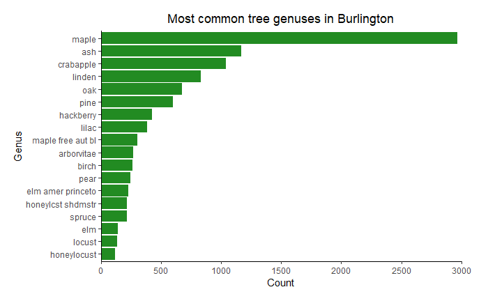

```r
# number of trees by species
# histogram
spec_hist <- trees %>% group_by(genus) %>% mutate(freq = n()) %>%
  filter(freq>100, genus!="NA", genus!="unknown") %>%
  ggplot(aes(x=reorder(genus, genus, function(x) length(x)))) +
  geom_bar(fill="forestgreen") +
  coord_flip() +
  labs(title="Most common tree genuses in Burlington", x="Genus", y="Count") +
  scale_y_continuous(expand=c(0,0), limits=c(0,3000), breaks=seq(0,3000,500)) +
  theme(panel.grid.major = element_blank(), panel.grid.minor = element_blank(), panel.border= element_blank(),
        plot.title=element_text(hjust=0.5), axis.line = element_line(), plot.margin=unit(c(0.5,1,0.5,0.5),"cm"))

spec_hist
```

This bar chart shows the most common tree genuses in Burlington. Unsurprisingly to anyone who lives in Vermont, the maple tree is by far the most common tree in Burlington. Next comes the Ash, Crabapple, Linden, Oak, and Pine. Considering Burlington’s climate and elevation, these all make sense. In the higher elevations of Vermont, evergreens such as pine trees are more common, but since Burlington is by the lake, it has the deciduous trees that make it beautiful in the fall (and barren in the spring).

## 2.3 Relationship between species abundance and Land Use

```r
# landuse v species
# multiple bar chart
# see if certain types of trees are more common by business, residential, etc.

# format the data into a new data fram
landuse_by_genus <- xtabs(formula = ~ landuse + genus,
                       data = trees) %>%
  prop.table(margin = "landuse") %>%  # calculates proportio

  # pipe into data.frame
  # Using data.frame() turns it from a table into a data frame
  data.frame() %>%
  filter(Freq > .1)

landuse_by_genus
```

| landuse | genus | Freq |
| --- | --- | --- |
| cemetery | arborvitae | 0.2431333 |
| apartments | ash | 0.1107474 |
| island | ash | 0.1138211 |
| residence | ash | 0.1145349 |
| business | crabapple | 0.1250000 |
| church | crabapple | 0.1538462 |
| parking lot | crabapple | 0.1165049 |
| street | crabapple | 0.3157895 |
| vacant lot | crabapple | 0.2258065 |
| street | elm | 0.4210526 |

[output cut: 31 more lines]

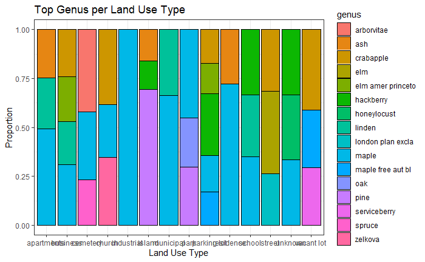

```r
landuse_species_bar <- ggplot(data = landuse_by_genus,
       mapping = aes(x = landuse,
                     fill = genus,
                     y = Freq)) +

  # Now we need to tell geom_bar() to override it'd default choice of y
  # We do this with stat = "identity" (identity means "Use the y I gave you!")
  geom_bar(color = "black",
           stat = "identity",
           position = "fill") +

  labs(y = "Proportion",
       title = "Top Genus per Land Use Type",
       x = "Land Use Type")


landuse_species_bar
```

## 2.4 The Trees of Burlington

```r
# will
# map of burlington with points as trees and colored by land use type
# map of burlington with points as trees and colored by species
# facet wrap them next to each other!
```

[output not shown]

## 2.5 Appraisal Estimates

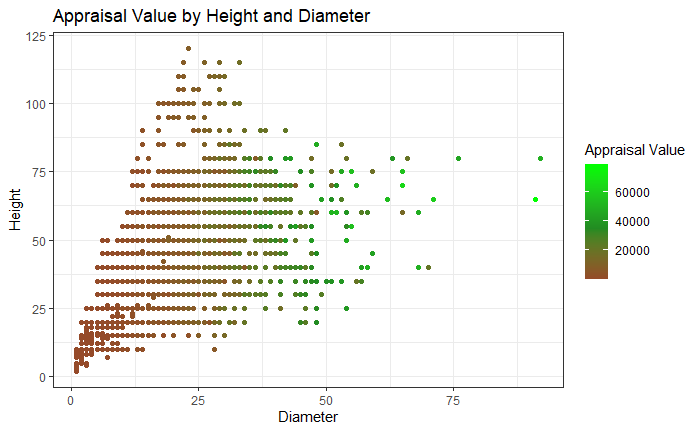

```r
# diameter v appraisal
# scatterplot probably
appraisal <- trees %>% filter(appraise != "NA", diameter != "NA", height != "NA") %>%
  ggplot(mapping=aes(x=diameter,y=height, color=appraise)) +
  geom_point() +
  scale_color_gradient2(low = 'brown', high = 'green', midpoint=35000, mid="forestgreen") +
  labs(title="Appraisal Value by Height and Diameter", x="Diameter", y="Height", color="Appraisal Value")


appraisal
```

This graph shows the relationship between a tree’s diameter, height, and appraisal value. It is clear that there is a relationship between diameter and height, and thicker trees are usually taller. From this plot, it is clear that diameter is more influential than height for a tree’s value. The trees with relatively high height and small diameter are worth significantly less than the shorter, thicker trees. This probably has to do with the way that trees age “outwards,” making their diameter a better indicator of their age than their height. It seems that there are very few extremely valuable trees, and many trees which are small and cheap.

# 3 Machine Learning